# Chapter 8: Empirical Bayesian Hierarchical Modeling

## 8.1 Setup.

Same ish

```r
library(dplyr)
library(tidyr)
library(ggplot2)
library(readr)
NBA_2016 <- read_csv("~/Emekas Documents/R-Directory/NBA 2016.csv")
```

```r
shooting <- NBA_2016 %>%
  filter(FGA > 0) %>%
  mutate(FGN = FGA - FGM, average = FGM/FGA) %>%
  dplyr::select(Player, Team, PS, FGM, FGN, FGA, average)
# from chapter 3
alpha0 <- 39.23353
beta0 <- 48.72738
prior_mu <- (alpha0) / (alpha0 + beta0)
shooting_eb <- shooting %>%
  mutate(eb_estimate = ((FGM + alpha0) / (FGA + alpha0 + beta0)),
         alpha1 = alpha0 + FGM,
         beta1 = beta0 + FGN)
shooting_eb <- shooting_eb %>%
  mutate(alpha1 = alpha0 + FGM, beta1 = beta0 + FGN)
```

from chapter 7 we will perform beta binomial regression using the gamlss package so mu depends on the number of shots taken.

```r
library(gamlss)
fit <- gamlss(cbind(FGM, FGA - FGM) ~ log(FGA),
              data = dplyr::select(shooting, -PS),
              family = BB(mu.link = "identity"))
```

```
GAMLSS-RS iteration 1: Global Deviance = 4250.504
GAMLSS-RS iteration 2: Global Deviance = 4130.697
GAMLSS-RS iteration 3: Global Deviance = 4130.674
GAMLSS-RS iteration 4: Global Deviance = 4130.674
```

alpha0 and beta0 can be computed based on mu and sigma.

```r
shooting_eb <- shooting %>%
  mutate(mu = fitted(fit, "mu"),
         sigma = fitted(fit, "sigma"),
         alpha0 = mu / sigma,
         beta0 = (1 - mu) / sigma,
         alpha1 = alpha0 + FGM,
         beta1 = beta0 + FGA - FGM,
         estimate = alpha1 / (alpha1 + beta1))
```

Noow we have corrected for the confounding factor of FGA.

## 8.2 Right-handed and Left-handed Batters

Left handed batters tend to hit better than right-handed batters. Well, I’m using a basketball data set so I will use position (point guard, shooting guard, small foward, power foward, center) instead. position has a huge affect on FG% because centers like Deandre Jordan mostly shoot high percentage shots. Hopefully, this still works out.

```r
shooting %>%
  count(PS)
```

| PS | n |
| --- | --- |
| C | 70 |
| PF | 116 |
| PG | 101 |
| SF | 89 |
| SG | 114 |

relevel the factors so point guards are the baseline.

```r
shooting2 <- shooting
shooting2$PS <- factor(shooting2$PS, levels = c("PG", "SG", "SF", "PF", "C"))
fit2 <- gamlss(cbind(FGM, FGA - FGM) ~ log(FGA) + PS,
              data = shooting2,
              family = BB(mu.link = "identity"))
```

```
GAMLSS-RS iteration 1: Global Deviance = 4134.638
GAMLSS-RS iteration 2: Global Deviance = 3906.559
GAMLSS-RS iteration 3: Global Deviance = 3906.448
GAMLSS-RS iteration 4: Global Deviance = 3906.448
```

Now we look at the coeeficients

```r
library(broom)
tidy(fit2)
```

| parameter | term | estimate | std.error | statistic | p.value |
| --- | --- | --- | --- | --- | --- |
| mu | (Intercept) | 0.2943027770 | 0.017239848 | 17.07107771 | 1.716816e-51 |
| mu | log(FGA) | 0.0196865012 | 0.002694478 | 7.30623962 | 1.140817e-12 |
| mu | PSSG | -0.0001454816 | 0.006606590 | -0.02202068 | 9.824405e-01 |
| mu | PSSF | 0.0164611356 | 0.007056891 | 2.33263285 | 2.007643e-02 |
| mu | PSPF | 0.0590479001 | 0.006662337 | 8.86294054 | 1.495265e-17 |
| mu | PSC | 0.1064934182 | 0.007736647 | 13.76480224 | 1.294263e-36 |
| sigma | (Intercept) | -5.1448533212 | 0.079415377 | -64.78409509 | 4.038558e-242 |

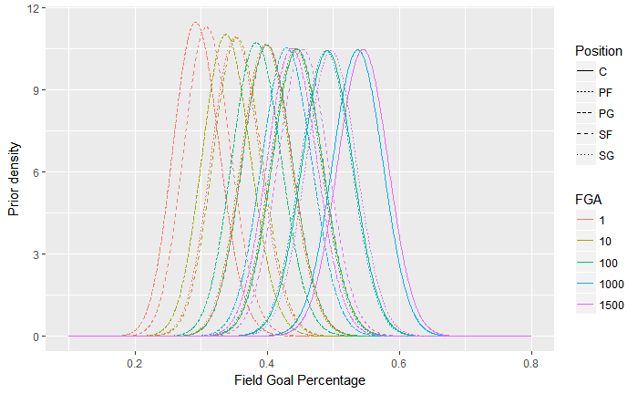

```r
sigma <- fitted(fit2, "sigma")[1]
crossing(PS = c("PG", "SG", "SF", "PF", "C"),
         FGA = c(1, 10, 100, 1000, 1500)) %>%
  augment(fit2, newdata = .) %>%
  rename(mu = .fitted) %>%
  crossing(x = seq(.1, .8, .0005)) %>%
  mutate(alpha = mu / sigma,
         beta = (1 - mu) / sigma,
         density = dbeta(x, alpha, beta)) %>%
  ggplot(aes(x, density, color = factor(FGA), lty = PS)) +
  geom_line() +
  labs(x = "Field Goal Percentage",
       y = "Prior density",
       color = "FGA",
       lty = "Position")
```

So this doesn’t really work too well with 5 different positions. So I’m going to redo this whole thing separating Guards and Forwards/Centers

```r
shooting3 <- shooting2
shooting3$PS <- gsub("PG", "Guard", shooting3$PS)
shooting3$PS <- gsub("SG", "Guard", shooting3$PS)
shooting3$PS <- gsub("SF", "Forward", shooting3$PS)
shooting3$PS <- gsub("PF", "Forward", shooting3$PS)
shooting3$PS <- gsub("C", "Forward", shooting3$PS)
shooting3$PS <- as.factor(shooting3$PS)
shooting3 <- shooting3 %>%
  mutate(PS = relevel(PS, "Guard"))
fit2 <- gamlss(cbind(FGM, FGA - FGM) ~ log(FGA) + PS,
              data = shooting3,
              family = BB(mu.link = "identity"))
```

```
GAMLSS-RS iteration 1: Global Deviance = 4190.567
GAMLSS-RS iteration 2: Global Deviance = 4019.567
GAMLSS-RS iteration 3: Global Deviance = 4019.535
GAMLSS-RS iteration 4: Global Deviance = 4019.535
```

```r
library(broom)
tidy(fit2)
```

| parameter | term | estimate | std.error | statistic | p.value |
| --- | --- | --- | --- | --- | --- |
| mu | (Intercept) | 0.29671792 | 0.018163864 | 16.335616 | 3.766546e-48 |
| mu | log(FGA) | 0.01925522 | 0.002931240 | 6.568966 | 1.303441e-10 |
| mu | PSForward | 0.05708906 | 0.005089821 | 11.216321 | 3.967922e-26 |
| sigma | (Intercept) | -4.78918896 | 0.067517250 | -70.932821 | 1.585201e-259 |

So forwards make shots about 5% more often than guards. It’s a statistically significant difference.

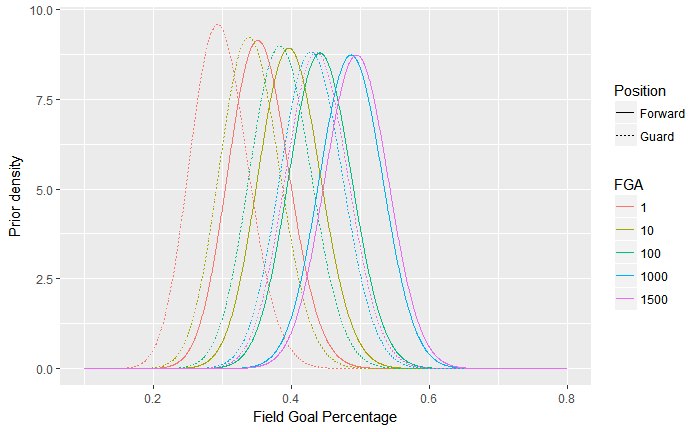

```r
sigma <- fitted(fit2, "sigma")[1]
crossing(PS = c("Guard", "Forward"),
         FGA = c(1, 10, 100, 1000, 1500)) %>%
  augment(fit2, newdata = .) %>%
  rename(mu = .fitted) %>%
  crossing(x = seq(.1, .8, .0005)) %>%
  mutate(alpha = mu / sigma,
         beta = (1 - mu) / sigma,
         density = dbeta(x, alpha, beta)) %>%
  ggplot(aes(x, density, color = factor(FGA), lty = PS)) +
  geom_line() +
  labs(x = "Field Goal Percentage",
       y = "Prior density",
       color = "FGA",
       lty = "Position")
```

The rest has to do with historical data which doesn’t work with my data so read the book for that part.